# BIOST 578 - Final Project - RNA-seq analysis with DER Finder

3/5/2015

## Differential expression analysis of RNA-seq data at single-base resolution

Authors: Alyssa Frazee, Sarven Sabunciyan, Kasper Hansen, Rafael Irizarry and Jeffrey Leek

Outline of talk:

- Introduction/motivations
- Overview of methods: linear models, HMMs, permutation tests
- Reproduction of some of the paper's results
- Discussion/questions

## Introduction & Review

### Microarrays and RNA-seq

The most common goal among investigators using either microarrays or RNA-seq is detecting differential expression.

- In microarrays, measurement units are fixed in advance, only the abundance on the specific RNA sequences that correspond to probes on the microarrays are measured. Within this approach, measurements from the same probe are compared across samples.

## Introduction & Review

### Microarrays and RNA-seq

- RNA-seq reads out short sequences of molecules produced by shearing and reading RNA transcripts. Unlike microarray, across-sample comparisons are not straightforward as measurement units are not defined in advance. Therefore, reads must be summarized into units of expression before differential expression analysis can be performed. Different summarization approaches can lead to very different statistical inference.

## Introduction & Review

### RNA-seq data analysis process

- First, each read must be matched to the position it originates from in the genome in a process called alignment.
- Then, the number of reads aligned to specific regions must be summarized into quantitative measurements.
- The measurements are then normalized for the total number of reads measured for a particular sample and statistical models are applied to the summarized units.

## Introduction & Review

Based on the summarization step, current differential expression analysis methods for RNA-seq data fall into two broad classes.

1. Annotate-then-identify, which quantify expression within the boundaries of genes previously published in databases.
2. Assemble-then-identify, which attempt to reconstruct full length RNA transcripts.

## Introduction & Review

### Annotate-then-identify

- Summarize the reads by counting the number that fall within pre-specified exons or genes, where the raw measurements take the form of counts. Annotations are obtained from database of previously identified genomic features.
- Two of the most widely used methods are EdgeR and DESeq.

## Introduction & Review

### Annotate-then-identify

- Advantage
1. This approach provides a straightforward and interpretable analysis. Once the raw read counts have been summarized into a gene-level matrix, the statistical problem is very similar to statistical analysis of microarray data. These methods are natural extensions of methods developed for microarrays.

## Introduction & Review

### Annotate-then-identify

- Disadvantage
1. This approach relies heavily on the accuracy of annotation databases of genes and exon boundaries, and current annotation may be unreliable or hard to interpret.
2. This approach does not allow for discovery of novel or previously uncharacterized exons or genes, since they rely on previously constructed databases.

## Introduction & Review

### Annotate-then-identify

Different choices in how to count may lead to dramatically different results. Also, there is not ‘correct’ gene model to use.

## Introduction & Review

### Assemble-then-identify

- Reconstruct the full-length transcript sequences from short reads.
- Estimate the relative abundances of transcripts.
- Predict which transcripts have different abundance between the two samples.

## Introduction & Review

### Assemble-then-identify

- Advantage
1. This approach relies less heavily on annotation databases of exon or gene boundaries.
2. This approach aims to fully quantify all the potential isoforms of mRNA molecules emanating from each gene.

## Introduction & Review

### Assemble-then-identify

- Disadvantage
1. It is virtually impossible to determine which of many possible sets of assembled transcripts truly generated the observed RNA-seq data. This ambiguity leads to varying and structured covariances between transcript measurements within genes, which complicates statistical analysis.
2. There is also an increased computational cost associated with assembling full transcripts, quantifying their abundances, and performing transcript-level statistical tests.

## Introduction & Review

### Identify-then-annotate

- First summarize the reads by counting the number of reads with alignments overlapping each individual base in the genome.
- Then a base-by-base statistical test is performed to identify bases that are differentially expressed between groups. Consecutive bases showing a common differential expression signature are grouped into differentially expressed regions (DERs).
- The unit of statistical analysis is then the DER, which can be compared with previous databases of exons and genes to identify regions of differentially expression corresponding to known exons or genes and novel regions of differential expression.

## Introduction & Review

### Identify-then-annotate

- Advantage
1. Allows for detection of differential expression in regions outside of exons or genes.
2. Allows for direct evaluation of differential expression of known exons and genes.
3. Does not incur the added ambiguity and computational cost of assembly from short reads.
4. Can detect differential splicing patterns and other expression differences between populations.

## Introduction & Review

### Identify-then-annotate

- Disadvantage
1. Does not allow for direct quantification of alternative transcription. Regions of potential alternative transcription can be easily identified where a subset of exons for a gene overlaps DERs but another subset does not, and those regions could be explored further with other tools.

## Methods - Outline

1. Quantify DE at each base using linear model framework
2. Identify DERs using HMM
3. Assess significance of DERs using permutation test

## Methods - Quantify DE at each base using linear model framework

- A coverage matrix has rows corresponding to bases and columns corresponding to samples.
- Each entry \(Y_{ij}\) of the coverage matrix is the number of aligned reads from from sample \(i\) that overlap base \(j\).
- We fit a linear regression model to each row of the coverage matrix: \[g(Y_{ij}) = \alpha(l_j) + \beta(l_j)X_{pi} + \sum_{k=1}^K \gamma_k(l_j)W_{ik} + \epsilon_{ij}\]

## Methods - Quantify DE at each base using linear model framework (cont.)

- \[g(Y_{ij}) = \alpha(l_j) + \beta(l_j)X_i + \sum_{k=1}^K \gamma_k(l_j)W_{ik} + \epsilon_{ij}\]
- \(\alpha(l_j)\): baseline gene expression (coverage)
- \(X_{i}\): indicator of whether sample \(i\) is a case or a control
- \(\beta(l_j)\): parameter of interest quantifying differential expression between case and control at location \(l_j\).
- \(W_{ik}\): values of potential confounders for sample \(i\) (e.g. GC content effect).
- \(\epsilon_{ij}\): residual measurement error at location \(j\).

## Methods - Identify DERs using HMMs

- \(H_0: \beta(l_j) = 0\)
- test statistic: \(s(l_j)\), which is modeled by Hidden Markov models (HMMs).
- Assume the genome \(D(l)\) has three hidden states:
1. \(D(l) = 0\) if \(\alpha(l) = \beta(l) = 0\)
2. \(D(l) = 1\) if \(\alpha(l) \neq 0\) and \(\beta(l) = 0\): regions for which gene expression is observed but does not differ between populations.
3. \(D(l) = 2\) if \(\beta(l) \neq 0\): regions in the differentially expressed state.

## Methods - Identify DERs using HMMs (cont.)

- Each hidden state has a probability, which is roughly estimated based on the relative frequencies of bases covered or not covered by genes, along with a prior estimate of the number of differentially expressed genes.
- We assume the \(s(l)\) follows a normal distribution, conditional on the hidden state of each base \(l\).
- We then estimate the unovserved states \(D(l)\) based on the observed statistics \(s(l)\) using HMMs.

## Methods - Assess significance of DERs using permutation test

- The HMM segments the genome into regions, where a region is defined as a set of continuous bases having the same predicted latent state.
- We refer to a region with predicted latent state \(D(l)=2\) as a candidate DER.
- The average base-level test statistic within each potential DER \(r\) is \(\bar{s}_r = \sum_{l \in DER_r}s(l)\).

## Methods - Assess significance of DERs using permutation test (cont.)

The permutation procedure:

1. Permute the each column (sample \(i\)) in the coverage matrix.
2. Re-calculate the base-level statistics based on the linear model, which is denoted as the null statistics \(s^0(l)\).
3. Re-run the HMM on the \(s^0(l)\) to identify a set of null DERs: \(DER^0_{\rho}\).
4. Calculate the null test statistics for each region and their averages: \(\bar{s}^0_{\rho} = \sum_{l \in DER^0_\rho}s^0(l)\).

## Methods - Assess significance of DERs using permutation test (cont.)

- Repeat the permutation percedure \(B\) times, and calculate \[p_r = \frac{\sum^B_{b=1}\sum^{P_b}_{\rho=1}I(\bar{s}^0_{\rho}>\bar{s_r})}{\sum^B_{b=1}P_b}\]

where \(P_b\) is the number of null DERs for permutation \(b\).

- This is the percent of null DERs with average statistic as or more extreme than the observed statistic for candidate DER \(r\) calculated on the observed data.

## Results - Running DER Finder on example data

The Experiment:

- RNA-seq reads from brain tissue
- 9 human males, 6 females
- Data processing:
  - Alignment using Tophat
  - Calculating coverage and generating the coverage matrix
- Test for DE on Y chromosome using DER Finder, Cufflinks, EdgeR, and DESeq
  - Compare males to females
  - Compare males to other males
  - Why?

## Results - Step one: fitting the model for each base

- Fit the model (this should look familiar..)

```r
# Sex of subjet for each sample (our covariate)
sex = c(1, 1, 0, 0, 1, 1, 0, 0, 1, 1, 1, 1, 0, 0, 1)
# Fit linear model using LIMMA
limma.input = getLimmaInput(dbfile = dbfile, tablename = tablename, group = sex,
    nonzero = TRUE)
# Save the ID for each position where model was fit
pos = limma.input$pos
# get moderated t-stats and lfc
tstats = getTstats(fit = limma.input$ebobject, trend = TRUE)
tt = tstats$tt
logfchange = tstats$logfchange
```

## Results - Finding the DERs, assessing significance, matching to annotated exons

- Step two: group bases into regions using HMMs (`getRegions` function)
- Step three: assess significance of each regoin using a permutation test
- Adjust p-values using Storey and Tibshirani method for controlling FDR
- Step four [optional]: match identified regions to previously annotated exons

These steps take awhile…

## Reproducing results: P-values for males versus males

This looks (somewhat) like what we would expect (i.e., uniform).

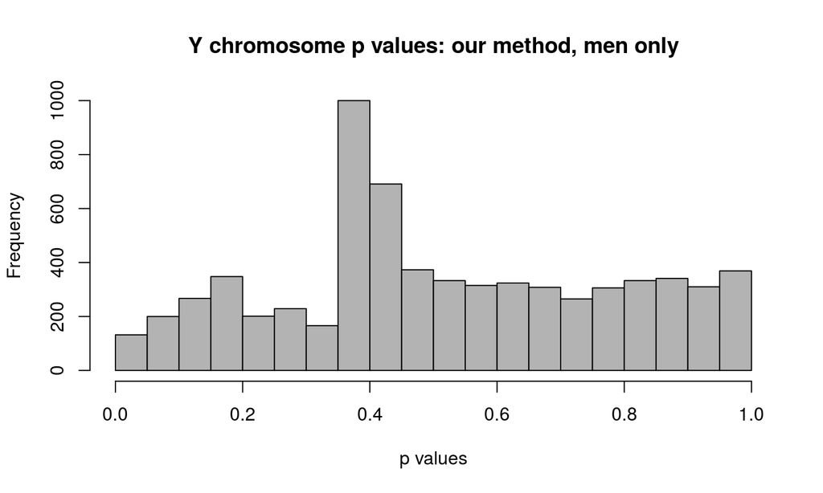

## Reproducing results: P-values for males versus females

Does this look like what we would expect?

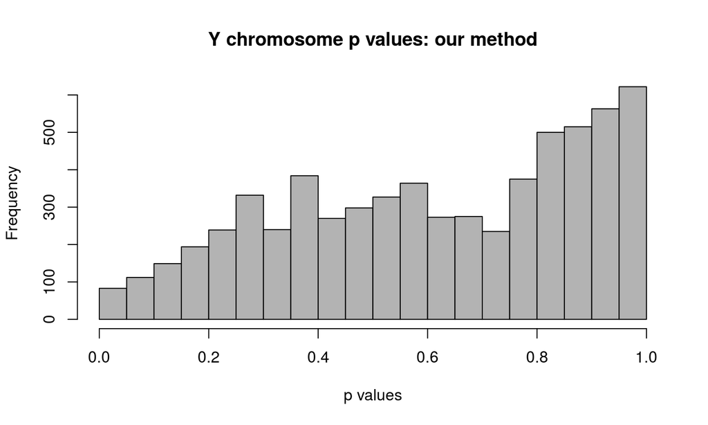

## Reproducing results: P-values for males versus females

This is what the p-values look like in the original paper:

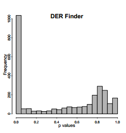

## Reproducing figures: MA plots

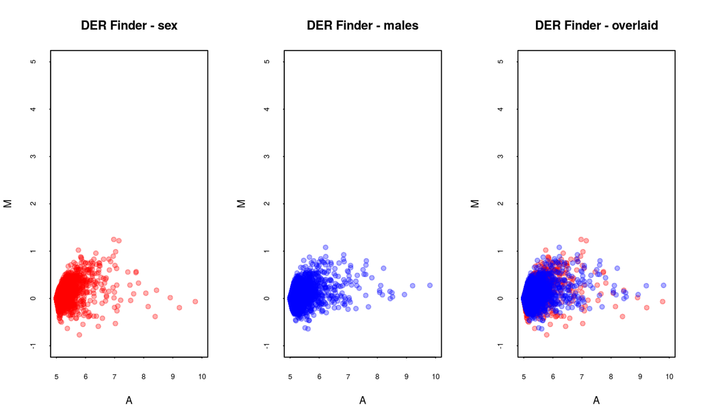

## Reproducing figures: MA plots

But the original figure looks like this. Just as we would expect, we see large fold changes in expression when comparing males to females, but not much change comparing males to each other.

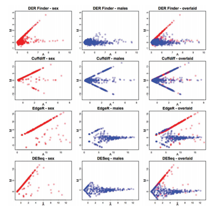

## Conclusions regarding DER Finder

The paper found:

- many DERs on Y chromosome between males and females
- quite a few of those were novel (not previously annotated)
- no DE comparing males and males
- performance better than Cufflinks, comparable with EdgeR and DESeq
- major advantage: is not limited to previously annotated features

## Conclusions regarding our reproduction of results

We were able to:

- Download and process the data
- Calculate coverage, generate a coverage matrix, fit the linear model, find DERs, and assess their significance
- Reproduce some of their figures

However, clearly something has gone wrong somewhere in this process.

## Reproducing results: Issues encountered

The `derfinder` package was written in an older version of R. Since then, some things have changed…

- functions deprecated
- updates made, bugs fixed in packages
- packages removed from CRAN
- updates made to public databases (such as Ensembl genome used for annotation)

Conclusion: Even "reproducible research" is not always easy to reproduce!

## Questions?

Our full code, data, and results files are available at: https://github.com/kegrinde/BIOST_578_Final_Project_Group_3

Github repo for DER Finder: https://github.com/alyssafrazee/derfinder

More information about DER Finder and other work by the first author at: http://alyssafrazee.com/